# BondValuation: An R Package for Fixed Coupon Bond Analysis

### 2.2 Bond-specific temporal structure

The function `AnnivDates()` evaluates bond-specific information and returns the bond’s time-invariant characteristics in the data frame `Traits`, the bond’s temporal structure in the data frame `DateVectors` and, if the nominal interest rate is passed, the bond’s cash flows in the data frame `PaySched`.[^4] The classes and formats of input data are checked and adjusted, if possible. Moreover, `AnnivDates()` performs several plausibility tests, *e.g.*, whether the provided calendar dates are in a correct chronological order and whether there are inconsistencies among the provided parameters. The results of these sanity checks are reported in the data frame `Warnings`.

The minimum accepted input for `AnnivDates()` are two calendar dates, of which the first is interpreted as the bond’s issue date and the second as its maturity date. If, as illustrated below, only two dates are passed to `AnnivDates()`, several parameters take on default values, which are reported in warning messages.

```r
> # example 3
> library(BondValuation)
> AnnivDates(as.Date("2019-05-31"), "2021-07-31")
\$`Warnings`
Em_FIAD_differ    EmMatMissing    CpYOverride   RV_set100percent     NegLifeFlag
             0               0              1                  1               0
      ZeroFlag   Em_Mat_SameMY ChronErrorFlag    FIPD_LIPD_equal IPD_CpY_Corrupt
             0               0              0                  0               0
 EOM_Deviation     EOMOverride    DCCOverride            NoCoups
             0               1              1                  0
\$Traits
DateOrigin           CpY           FIAD           Em      Em_Orig          FIPD
1970-01-01             2           <NA>   2019-05-31   2019-05-31          <NA>
 FIPD_Orig      est_FIPD           LIPD    LIPD_Orig     est_LIPD           Mat
      <NA>    2019-07-31           <NA>         <NA>   2021-01-31    2021-07-31
     Refer       FCPType      FCPLength      LCPType    LCPLength           Par
2021-07-31         short      0.3370166      regular            1           100
CouponInPercent.p.a  DayCountConvention     EOM_Orig      est_EOM      EOM_used
                 NA                   2           NA            1             1

\$DateVectors
 RealDates   RD_indexes    CoupDates   CD_indexes   AnnivDates   AD_indexes
2019-05-31    0.6629834   2019-07-31            1   2019-01-31            0
2019-07-31    1.0000000   2020-01-31            2   2019-07-31            1
2020-01-31    2.0000000   2020-07-31            3   2020-01-31            2
2020-07-31    3.0000000   2021-01-31            4   2020-07-31            3
2021-01-31    4.0000000   2021-07-31            5   2021-01-31            4
2021-07-31    5.0000000         <NA>           NA   2021-07-31            5

Warning messages:
1: In InputFormatCheck(Em = Em, Mat = Mat, CpY = CpY, FIPD = FIPD,  :
   The maturity date (Mat) is supplied as a string of class "character" in the
   format "yyyy-mm-dd". It is converted to class "Date" using the command
   "as.Date(Mat,"%Y-%m-%d")" and processed as Mat = 2021-07-31 .
2: In AnnivDates(as.Date("2019-05-31"), "2021-07-31") :
   Number of interest payments per year (CpY) is missing or NA. CpY is set 2!
3: In AnnivDates(as.Date("2019-05-31"), "2021-07-31") :
   Redemption value (RV) is missing or NA. RV is set 100!
4: In AnnivDates(as.Date("2019-05-31"), "2021-07-31") :
   EOM was not provided or NA! EOM is set 1 .
   Note: The available calandar dates suggest that EOM = 1 .
5: In AnnivDates(as.Date("2019-05-31"), "2021-07-31") :
   The day count indentifier (DCC) is missing or NA. DCC is set 2 (Act/Act (ICMA))!
```

Since neither the first nor the penultimate coupon payment date is passed to `AnnivDates()`, the calendar dates in the data frame `DateVectors` are constructed backwards starting from the maturity date 2021-07-31. This results in a bond with a short first coupon period having a length of `$Traits$FCPLength = 0.3370166` regular coupon periods.

The data frame `DateVectors` contains three vectors of calendar dates, `RealDates`, `CoupDates`, and `AnnivDates`, and their corresponding indexes, `RD_indexes`, `CD_indexes`, and `AD_indexes`. The vector `RealDates` comprises the bond’s issue date, maturity date, and all coupon payment dates in between, while `CoupDates` contains only the coupon payment dates. The vector `AnnivDates` consists of the bond’s so-called anniversary dates, *i.e.*, scheduled coupon dates and notional coupon dates located before the first and after the penultimate coupon payment dates. The lengths of the first (`$Traits$FCPLength`) and final coupon periods (`$Traits$LCPLength`) are calculated as differences between the coresponding values of the vectors `AD_indexes` and `RD_indexes`. `RD_indexes` are used in the functions `BondVal.Price()`, `BondVal.Yield()`, and `DP()` to determine the powers of discount factors in pricing formulas.

As warning message 4 in the example above reports, the function `AnnivDates()` analyzes the provided calendar dates to ascertain whether the bond follows the End-of-Month rule (`EOM`). An automated replacement of the provided value of `EOM` by the value determined by the function `AnnivDates()` can be activated by setting option `FindEOM = TRUE`, which defaults to `FALSE`.

The following example illustrates the effect of `EOM` on `DateVectors`. In addition to issue date (`Em`) and maturity date (`Mat`), the first coupon payment date (`FIPD`), the penultimate coupon payment date (`LIPD`), the number of coupon payments p.a. (`CpY`), and `EOM` are passed to the function `AnnivDates()`:

```r
> # example 4
> library(BondValuation)
> # example 4a: computing DateVectors for EOM = 1
> EOM.input <- 1
> AnnivDates(Em = as.Date("2019-05-31"),
+            Mat = as.Date("2021-07-31"),
+            CpY = 2,
+            FIPD = as.Date("2020-02-29"),
+            LIPD = as.Date("2021-02-28"),
+            EOM = EOM.input)\$DateVectors
   RealDates   RD_indexes    CoupDates   CD_indexes   AnnivDates   AD_indexes
1 2019-05-31    -0.500000   2020-02-29     1.000000   2019-02-28           -1
2 2020-02-29     1.000000   2020-08-31     2.000000   2019-08-31            0
3 2020-08-31     2.000000   2021-02-28     3.000000   2020-02-29            1
4 2021-02-28     3.000000   2021-07-31     3.831522   2020-08-31            2
5 2021-07-31     3.831522         <NA>           NA   2021-02-28            3
6       <NA>           NA         <NA>           NA   2021-08-31            4
Warning messages:
1: In AnnivDates(Em = as.Date("2019-05-31"), Mat = as.Date("2021-07-31"),  :
   Redemption value (RV) is missing or NA. RV is set 100!
2: In AnnivDates(Em = as.Date("2019-05-31"), Mat = as.Date("2021-07-31"),  :
   The day count indentifier (DCC) is missing or NA. DCC is set 2 (Act/Act (ICMA))!
>
> # example 4b: computing DateVectors for EOM = 0
> EOM.input <- 0
> AnnivDates(Em = as.Date("2019-05-31"),
+            Mat = as.Date("2021-07-31"),
+            CpY = 2,
+            FIPD = as.Date("2020-02-29"),
+            LIPD = as.Date("2021-02-28"),
+            EOM = EOM.input)\$DateVectors
   RealDates   RD_indexes    CoupDates   CD_indexes   AnnivDates   AD_indexes
1 2019-05-31   -0.4945055   2020-02-29     1.000000   2019-02-28           -1
2 2020-02-29    1.0000000   2020-08-29     2.000000   2019-08-29            0
3 2020-08-29    2.0000000   2021-02-28     3.000000   2020-02-29            1
4 2021-02-28    3.0000000   2021-07-31     3.840659   2020-08-29            2
5 2021-07-31    3.8406593         <NA>           NA   2021-02-28            3
6       <NA>           NA         <NA>           NA   2021-08-29            4
Warning messages:
1: In AnnivDates(Em = as.Date("2019-05-31"), Mat = as.Date("2021-07-31"),  :
   Redemption value (RV) is missing or NA. RV is set 100!
2: In AnnivDates(Em = as.Date("2019-05-31"), Mat = as.Date("2021-07-31"),  :
   The available calandar dates suggest that EOM = 1 .
   Option FindEOM = FALSE is active. Provided EOM is not overridden and remains
   EOM = 0 .
3: In AnnivDates(Em = as.Date("2019-05-31"), Mat = as.Date("2021-07-31"),  :
   The day count indentifier (DCC) is missing or NA. DCC is set 2 (Act/Act (ICMA))!
```

In contrast to *example 3*, the bond in *example 4* features a long first and a short final coupon period. The function `AnnivDates()` has checked whether the provided dates `FIPD` and `LIPD` are on each other’s annivesary dates and constructed the calendar dates in `DateVectors` backwards and forwards from `LIPD`. The values of `RD_indexes` and `AD_indexes` are illustrated in 1, where $E$ corresponds to the first element of `RD_indexes` and $M$ is the final element of `RD_indexes`.

As shown in *example 4*, all else equal, the value of `EOM` affects the `DCC`-conformal temporal locations of the issue date $E$ and the maturity date $M$ and, hence, the lengths of the first and final coupon periods, which, in turn, determine the amounts of interest paid on the first and final coupon payment dates. So far, no value of `DCC` was passed to the function `AnnivDates()`. As reported in the warning messages in *example 4*, the parameter `DCC` defaults to the *Act/Act (ICMA)* convention. The following, *example 5*, illustrates how `RD_indexes`, `FCPLength` and `LCPLength` vary across `DCC`s for `EOM = 0`.

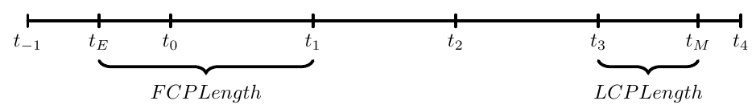

Figure 1: Timeline illustration of the bonds in examples 4 and 5.

```r
> # example 5
> library(BondValuation)
> TempStruct.by.DCC <- data.frame(Em = rep(as.Date("2019-05-31"), 16),
+                                 Mat = rep(as.Date("2021-07-31"), 16),
+                                 CpY = rep(2, 16),
+                                 FIPD = rep(as.Date("2020-02-29"), 16),
+                                 LIPD = rep(as.Date("2021-02-28"), 16),
+                                 FIAD = rep(as.Date("2019-05-31"), 16),
+                                 DCC = seq(1, 16),
+                                 EOM = rep(0, 16),
+                                 DCC.Name = List.DCC[, 2])
> # Applying AnnivDates() to the data frame TempStruct.by.DCC for EOM = 0
> suppressWarnings(
+   FullAnalysis.EOM0 <- apply(
+     TempStruct.by.DCC[, c('Em','Mat','CpY','FIPD','LIPD','FIAD','DCC','EOM')],
+     1, function(y) AnnivDates(
+       y[1], y[2], y[3], y[4], y[5], y[6], , , y[7], y[8])
+   )
+ )
> FCPLength.EOM0 <- lapply(lapply(lapply(FullAnalysis.EOM0, `[[`, 2), `[[`, 15)
+                          , na.omit)
> FCPLength.EOM0 <- as.data.frame(do.call(rbind, lapply(FCPLength.EOM0, round, 4)))
> LCPLength.EOM0 <- lapply(lapply(lapply(FullAnalysis.EOM0, `[[`, 2), `[[`, 17)
+                          , na.omit)
> LCPLength.EOM0 <- as.data.frame(do.call(rbind, lapply(LCPLength.EOM0, round, 4)))
> TempStruct.EOM0 <- lapply(lapply(lapply(FullAnalysis.EOM0, `[[`, 3), `[[`, 2)
+                           , na.omit)
> TempStruct.EOM0 <- lapply(TempStruct.EOM0, `length<-`,
+                           max(lengths(TempStruct.EOM0)))
> TempStruct.EOM0 <- as.data.frame(do.call(rbind, lapply(TempStruct.EOM0, round, 4)))
> TempStruct.by.DCC.EOM0 <- cbind(TempStruct.by.DCC, TempStruct.EOM0,
+                                 FCPLength.EOM0, LCPLength.EOM0)
> names(TempStruct.by.DCC.EOM0)[c(10:16)] <- c("E", "01", "02", "03", "M",
+                                              "FCPLength", "LCPLength")
> print(TempStruct.by.DCC.EOM0[, c(9:ncol(TempStruct.by.DCC.EOM0))],
+       row.names = FALSE)
               DCC.Name         E   01   02   03        M  FCPLength  LCPLength
         ACT/ACT (ISDA)   -0.4945    1    2    3   3.8407     1.4945     0.8407
         ACT/ACT (ICMA)   -0.4945    1    2    3   3.8407     1.4945     0.8407
          ACT/ACT (AFB)   -0.4945    1    2    3   3.8407     1.4945     0.8407
               ACT/365L   -0.4945    1    2    3   3.8407     1.4945     0.8407
                 30/360   -0.4862    1    2    3   3.8453     1.4862     0.8453
                30E/360   -0.4917    1    2    3   3.8398     1.4917     0.8398
         30E/360 (ISDA)   -0.4972    1    2    3   3.8380     1.4972     0.8380
        30/360 (German)   -0.4972    1    2    3   3.8380     1.4972     0.8380
              30/360 US   -0.4862    1    2    3   3.8453     1.4862     0.8453
        ACT/365 (Fixed)   -0.4945    1    2    3   3.8407     1.4945     0.8407
            ACT(NL)/365   -0.4945    1    2    3   3.8407     1.4945     0.8407
                ACT/360   -0.4945    1    2    3   3.8407     1.4945     0.8407
                 30/365   -0.4862    1    2    3   3.8453     1.4862     0.8453
ACT/365 (Canadian Bond)   -0.4945    1    2    3   3.8407     1.4945     0.8407
                ACT/364   -0.4945    1    2    3   3.8407     1.4945     0.8407
 BusDay/252 (Brazilian)   -0.5040    1    2    3   3.8425     1.5040     0.8425
```

The output of *example 5* shows that for the specified bond, there is little variation in temporal structure across the `DCC`s. Specifically, with `DCC` $\in \{1,\ 2,\ 3,\ 4,\ 10,\ 11,\ 12,\ 14,\ 15\}$, the values of `RD_indexes` are $\{-0.4945,\ 1,\ 2,\ 3,\ 3.8407\}$; with `DCC` $\in \{5,\ 9,\ 13\}$, it holds `RD_indexes` $= \{-0.4862,\ 1,\ 2,\ 3,\ 3.8453\}$, and with `DCC` $\in \{7,\ 8\}$, we get `RD_indexes` $= \{-0.4972,\ 1,\ 2,\ 3,\ 3.8380\}$. Only the `DCC`s $6$ and $16$ produce a unique temporal structure for this bond. Nevertheless, it would be wrong to infer from this that the temporal structure always has so little variation across the `DCC`s, as *example 6* illustrates.

```r
> # example 6
> library(BondValuation)
> TempStruct.by.DCC <- data.frame(Em = rep(as.Date("2019-10-31"), 16),
+                                 Mat = rep(as.Date("2024-02-29"), 16),
+                                 CpY = rep(2, 16),
+                                 FIPD = rep(as.Date("2020-03-30"), 16),
+                                 LIPD = rep(as.Date("2023-03-30"), 16),
+                                 FIAD = rep(as.Date("2019-10-31"), 16),
+                                 DCC = seq(1, 16),
+                                 EOM = rep(0, 16),
+                                 DCC.Name = List.DCC[, 2])
>
> # Applying AnnivDates() to the data frame TempStruct.by.DCC for EOM = 0
> suppressWarnings(
+   FullAnalysis.EOM0 <- apply(
+     TempStruct.by.DCC[, c('Em','Mat','CpY','FIPD','LIPD','FIAD','DCC','EOM')],
+     1, function(y) AnnivDates(
+       y[1], y[2], y[3], y[4], y[5], y[6], , , y[7], y[8])
+   )
+ )
> FCPLength.EOM0 <- lapply(lapply(lapply(FullAnalysis.EOM0, `[[`, 2), `[[`, 15)
+                          , na.omit)
> FCPLength.EOM0 <- as.data.frame(do.call(rbind, lapply(FCPLength.EOM0, round, 4)))
> LCPLength.EOM0 <- lapply(lapply(lapply(FullAnalysis.EOM0, `[[`, 2), `[[`, 17)
+                          , na.omit)
> LCPLength.EOM0 <- as.data.frame(do.call(rbind, lapply(LCPLength.EOM0, round, 4)))
> TempStruct.EOM0 <- lapply(lapply(lapply(FullAnalysis.EOM0, `[[`, 3), `[[`, 2)
+                           , na.omit)
> TempStruct.EOM0 <- lapply(TempStruct.EOM0, `length<-`,
+                           max(lengths(TempStruct.EOM0)))
> TempStruct.EOM0 <- as.data.frame(do.call(rbind, lapply(TempStruct.EOM0, round, 4)))
> TempStruct.by.DCC.EOM0 <- cbind(TempStruct.by.DCC, TempStruct.EOM0,
+                                 FCPLength.EOM0, LCPLength.EOM0)
> names(TempStruct.by.DCC.EOM0)[c(10:20)] <- c("E","01","02","03","04","05","06",
+                                              "07","M","FCPLength","LCPLength")
> print(TempStruct.by.DCC.EOM0[, c(9:ncol(TempStruct.by.DCC.EOM0))],
+       row.names = FALSE)
               DCC.Name       E 01 02 03 04 05 06 07      M FCPLength LCPLength
         ACT/ACT (ISDA)  0.1706  1  2  3  4  5  6  7 8.8354    0.8294    1.8354
         ACT/ACT (ICMA)  0.1703  1  2  3  4  5  6  7 8.8352    0.8297    1.8352
          ACT/ACT (AFB)  0.1708  1  2  3  4  5  6  7 8.8375    0.8292    1.8375
               ACT/365L  0.1703  1  2  3  4  5  6  7 8.8352    0.8297    1.8352
                 30/360  0.1667  1  2  3  4  5  6  7 8.8278    0.8333    1.8278
                30E/360  0.1667  1  2  3  4  5  6  7 8.8278    0.8333    1.8278
         30E/360 (ISDA)  0.1667  1  2  3  4  5  6  7 8.8278    0.8333    1.8278
        30/360 (German)  0.1667  1  2  3  4  5  6  7 8.8333    0.8333    1.8333
              30/360 US  0.1667  1  2  3  4  5  6  7 8.8278    0.8333    1.8278
        ACT/365 (Fixed)  0.1703  1  2  3  4  5  6  7 8.8352    0.8297    1.8352
            ACT(NL)/365  0.1713  1  2  3  4  5  6  7 8.8398    0.8287    1.8398
                ACT/360  0.1703  1  2  3  4  5  6  7 8.8352    0.8297    1.8352
                 30/365  0.1667  1  2  3  4  5  6  7 8.8278    0.8333    1.8278
ACT/365 (Canadian Bond)  0.1703  1  2  3  4  5  6  7 8.8352    0.8297    1.8352
                ACT/364  0.1703  1  2  3  4  5  6  7 8.8352    0.8297    1.8352
 BusDay/252 (Brazilian)  0.1840  1  2  3  4  5  6  7 8.8279    0.8160    1.8279
```

The output of *example 6* reveals that, all else equal, the specified bond can feature $7$ different temporal structures, depending on the stipulated `DCC`. While in *example 5* the “ACT/ACT” family of `DCC`s produced the same temporal structure, in *example 6* most of the “30/360” `DCC`s result in the same day count.

### 2.3 Cash flows, accrued interest, and dirty price

In the preceding examples of `AnnivDates()`, no information on nominal interest rate (`Coup`) and redemption value (`RV`) was passed to the function. If this information, however, is provided, then `AnnivDates()` generates the data frame `PaySched`, consisting of the scheduled coupon dates and the corresponding cash flows. As Djatschenko (2019) points out, precise application of the respective `DCC`’s mathematical rule results in varying interest payments. While this is intended for calculation of the cash flows paid at the ends of irregular first and final coupon periods, most issuers design their bonds to pay the same cash flow at the end of each regular period. With default `RegCF.equal = 0` the function `AnnivDates()` calculates all cash flows according to the mathematical rule of the respective `DCC`. Passing any other value to `RegCF.equal` forces all regular cash flows to be equal sized. The following, *example 7*, uses the same input as *example 6* supplemented by information on nominal interest rate p.a. (`Coup` $= 10 \%$) and redemption value (`RV` $= 100\%$) and illustrates the differences in cash flows (in percent of the bond’s par value) by `DCC` between the two modes of `RegCF.equal`.

```r
> # example 7
> library(BondValuation)
> CashFlows.by.DCC <- data.frame(Em = rep(as.Date("2019-10-31"), 16),
+                                Mat = rep(as.Date("2024-02-29"), 16),
+                                CpY = rep(2, 16),
+                                FIPD = rep(as.Date("2020-03-30"), 16),
+                                LIPD = rep(as.Date("2023-03-30"), 16),
+                                FIAD = rep(as.Date("2019-10-31"), 16),
+                                RV = rep(100, 16),
+                                Coup = rep(10, 16),
+                                DCC = seq(1, 16),
+                                EOM = rep(0, 16),
+                                DCC.Name = List.DCC[, 2])
>
> # Applying AnnivDates() to the data frame CashFlows.by.DCC for EOM = 0
> # with option RegCF.equal = 0 and RegCF.equal = 1
> Suffix <- c("RegCFvary","RegCFequal")
> for (i in c(0,1)) {
+   suppressWarnings(
+     FullAnalysis <- apply(
+       CashFlows.by.DCC[, c('Em','Mat','CpY','FIPD','LIPD','FIAD','RV',
+                            'Coup','DCC','EOM')],
+       1, function(y) AnnivDates(
+         y[1],y[2],y[3],y[4],y[5],y[6],y[7],y[8],y[9],y[10], RegCF.equal = i)
+     )
+   )
+   CashFlows <- lapply(lapply(lapply(FullAnalysis, `[[`, 4), `[[`, 2)
+                       , na.omit)
+   CashFlows <- as.data.frame(do.call(rbind, lapply(CashFlows, round, 4)))
+   CashFlows <- cbind(CashFlows.by.DCC, CashFlows)
+   names(CashFlows)[c(12:19)] <- c(
+     "CF.1","CF.2","CF.3","CF.4","CF.5","CF.6","CF.7","CF.M")
+   assign(paste0("CashFlows.by.DCC.",Suffix[i+1]),CashFlows)
+   rm(FullAnalysis,CashFlows)
+ }
>
> # RegCF.equal = 0, \textit{i.e.}, regular cash flows may vary
> print(CashFlows.by.DCC.RegCFvary[, c(11:ncol(CashFlows.by.DCC.RegCFvary))],
+       row.names = FALSE)
               DCC.Name   CF.1   CF.2   CF.3   CF.4   CF.5   CF.6   CF.7   CF.M
         ACT/ACT (ISDA) 4.1303 5.0273 4.9519 5.0411 4.9589 5.0411 4.9589 9.2011
         ACT/ACT (ICMA) 4.1484 5.0000 5.0000 5.0000 5.0000 5.0000 5.0000 9.1758
          ACT/ACT (AFB) 4.1257 5.0411 4.9589 5.0411 4.9589 5.0411 4.9589 9.2055
               ACT/365L 4.1257 5.0273 4.9589 5.0411 4.9589 5.0411 4.9589 9.1803
                 30/360 4.1667 5.0000 5.0000 5.0000 5.0000 5.0000 5.0000 9.1389
                30E/360 4.1667 5.0000 5.0000 5.0000 5.0000 5.0000 5.0000 9.1389
         30E/360 (ISDA) 4.1667 5.0000 5.0000 5.0000 5.0000 5.0000 5.0000 9.1389
        30/360 (German) 4.1667 5.0000 5.0000 5.0000 5.0000 5.0000 5.0000 9.1667
              30/360 US 4.1667 5.0000 5.0000 5.0000 5.0000 5.0000 5.0000 9.1389
        ACT/365 (Fixed) 4.1370 5.0411 4.9589 5.0411 4.9589 5.0411 4.9589 9.2055
            ACT(NL)/365 4.1096 5.0411 4.9589 5.0411 4.9589 5.0411 4.9589 9.2055
                ACT/360 4.1944 5.1111 5.0278 5.1111 5.0278 5.1111 5.0278 9.3333
                 30/365 4.1096 4.9315 4.9315 4.9315 4.9315 4.9315 4.9315 9.0137
ACT/365 (Canadian Bond) 4.1370 5.0000 5.0000 5.0000 5.0000 5.0000 5.0000 9.1644
                ACT/364 4.1484 5.0549 4.9725 5.0549 4.9725 5.0549 4.9725 9.2308
 BusDay/252 (Brazilian) 3.9332 4.8809 4.8809 4.8809 4.8809 4.8809 4.8809 9.0060
>
> # RegCF.equal = 1, \textit{i.e.}, regular cash flows forced to be equal
> print(CashFlows.by.DCC.RegCFequal[, c(11:ncol(CashFlows.by.DCC.RegCFequal))],
+       row.names = FALSE)
               DCC.Name   CF.1   CF.2   CF.3   CF.4   CF.5   CF.6   CF.7   CF.M
         ACT/ACT (ISDA) 4.1303 5.0000 5.0000 5.0000 5.0000 5.0000 5.0000 9.2011
         ACT/ACT (ICMA) 4.1484 5.0000 5.0000 5.0000 5.0000 5.0000 5.0000 9.1758
          ACT/ACT (AFB) 4.1257 5.0000 5.0000 5.0000 5.0000 5.0000 5.0000 9.2055
               ACT/365L 4.1257 5.0000 5.0000 5.0000 5.0000 5.0000 5.0000 9.1803
                 30/360 4.1667 5.0000 5.0000 5.0000 5.0000 5.0000 5.0000 9.1389
                30E/360 4.1667 5.0000 5.0000 5.0000 5.0000 5.0000 5.0000 9.1389
         30E/360 (ISDA) 4.1667 5.0000 5.0000 5.0000 5.0000 5.0000 5.0000 9.1389
        30/360 (German) 4.1667 5.0000 5.0000 5.0000 5.0000 5.0000 5.0000 9.1667
              30/360 US 4.1667 5.0000 5.0000 5.0000 5.0000 5.0000 5.0000 9.1389
        ACT/365 (Fixed) 4.1370 5.0000 5.0000 5.0000 5.0000 5.0000 5.0000 9.2055
            ACT(NL)/365 4.1096 5.0000 5.0000 5.0000 5.0000 5.0000 5.0000 9.2055
                ACT/360 4.1944 5.0000 5.0000 5.0000 5.0000 5.0000 5.0000 9.3333
                 30/365 4.1096 5.0000 5.0000 5.0000 5.0000 5.0000 5.0000 9.0137
ACT/365 (Canadian Bond) 4.1370 5.0000 5.0000 5.0000 5.0000 5.0000 5.0000 9.1644
                ACT/364 4.1484 5.0000 5.0000 5.0000 5.0000 5.0000 5.0000 9.2308
 BusDay/252 (Brazilian) 3.9332 4.8809 4.8809 4.8809 4.8809 4.8809 4.8809 9.0060
```

Please note that, irrespective of the value of `RegCF.equal` passed to `AnnivDates()`, the cash flows at the ends of all regular coupon periods are equal sized with the conventions *ACT/ACT (ICMA)*, *ACT/365 (Canadian Bond)*, and *BusDay/252 (Brazilian)*. This is due to the `DCC`-specific rules described in Djatschenko (2019). While with the majority of `DCC`s, the cash flows are computed based upon the ratio of the nominal interest rate p.a. and the number of interest payments per year, which yields regular cash flows of $5 \%$, *BusDay/252 (Brazilian)* determines them exponentially, resulting in regular cash flows of $4.8809 \%$.

The vast majority of bonds are quoted clean, *i.e.*, their observable prices do not contain accrued interest. The actual price that a bond buyer pays to the seller is called full or dirty price and computed as the sum of the quoted clean price and accrued interest, which is calculated according to the respective `DCC`. Accrued interest and the dirty price of a specific bond can be calculated using the function `DP()`. In addition to the input parameters required by `AnnivDates()`, the clean price (`CP`) and the settlement date (`SETT`) need to be passed to the function `DP()`. The following, *example 8*, returns the accrued interest and dirty price by `DCC` for the same bond as used in *example 7*, assuming that on the settlement dates `SETT1 = 2020-09-28`, `SETT2 = 2023-03-30`, and `SETT3 = 2024-01-15`, the quoted clean price is $105\%$ of the bond’s par value.

```r
> # example 8
> library(BondValuation)
> AccrIntDP.by.DCC <- data.frame(CP = 105,
+                                SETT1 = rep(as.Date("2020-09-28"), 16),
+                                SETT2 = rep(as.Date("2023-03-30"), 16),
+                                SETT3 = rep(as.Date("2024-01-15"), 16),
+                                Em = rep(as.Date("2019-10-31"), 16),
+                                Mat = rep(as.Date("2024-02-29"), 16),
+                                CpY = rep(2, 16),
+                                FIPD = rep(as.Date("2020-03-30"), 16),
+                                LIPD = rep(as.Date("2023-03-30"), 16),
+                                FIAD = rep(as.Date("2019-10-31"), 16),
+                                RV = rep(100, 16),
+                                Coup = rep(10, 16),
+                                DCC = seq(1, 16),
+                                EOM = rep(0, 16),
+                                DCC.Name = List.DCC[, 2])
>
> Suffix <- c("SETT1","SETT2","SETT3")
> for (i in c(1:3)) {
+   DP.Output<-suppressWarnings(
+     apply(AccrIntDP.by.DCC[,c('CP',paste0('SETT',i),'Em','Mat','CpY','FIPD',
+                               'LIPD','FIAD','RV','Coup','DCC')],
+           1,function(y) DP(y[1],y[2],y[3],y[4],y[5],y[6],y[7],
+                            y[8],y[9],y[10],y[11])))
+   AI<-do.call(rbind,lapply(lapply(lapply(DP.Output, `[[`, 2), `[[`, 3), round, 4))
+   DP<-do.call(rbind,lapply(lapply(lapply(DP.Output, `[[`, 2), `[[`, 1), round, 4))
+   AccrIntDP.by.DCC<-cbind(AccrIntDP.by.DCC,AI,DP)
+   names(AccrIntDP.by.DCC)[
+     c((ncol(AccrIntDP.by.DCC) - 1) : ncol(AccrIntDP.by.DCC))] <- c(
+     paste0("AI.", Suffix[i]), paste0("DP.", Suffix[i]))
+   rm(DP.Output,AI,DP)
+ }
> print(AccrIntDP.by.DCC[,c(15:ncol(AccrIntDP.by.DCC))], row.names = FALSE)
               DCC.Name AI.SETT1 DP.SETT1 AI.SETT2 DP.SETT2 AI.SETT3 DP.SETT3
         ACT/ACT (ISDA)   4.9727 109.9727        0      105   7.9716 112.9716
         ACT/ACT (ICMA)   4.9457 109.9457        0      105   7.9396 112.9396
          ACT/ACT (AFB)   4.9863 109.9863        0      105   7.9726 112.9726
               ACT/365L   4.9727 109.9727        0      105   7.9508 112.9508
                 30/360   4.9444 109.9444        0      105   7.9167 112.9167
                30E/360   4.9444 109.9444        0      105   7.9167 112.9167
         30E/360 (ISDA)   4.9444 109.9444        0      105   7.9167 112.9167
        30/360 (German)   4.9444 109.9444        0      105   7.9167 112.9167
              30/360 US   4.9444 109.9444        0      105   7.9167 112.9167
        ACT/365 (Fixed)   4.9863 109.9863        0      105   7.9726 112.9726
            ACT(NL)/365   4.9863 109.9863        0      105   7.9726 112.9726
                ACT/360   5.0556 110.0556        0      105   8.0833 113.0833
                 30/365   4.8767 109.8767        0      105   7.8082 112.8082
ACT/365 (Canadian Bond)   4.9863 109.9863        0      105   7.9315 112.9315
                ACT/364   5.0000 110.0000        0      105   7.9945 112.9945
 BusDay/252 (Brazilian)   4.8412 109.8412        0      105   7.7354 112.7354
```

### 2.4 Yield to maturity, duration, and convexity

The yield to maturity p.a. is determined as the value $y$ that fulfills equation ((1)).

$$\label{eq:MidPeriodTVM_odd}
DP_{\tau} =
CP_{\tau} + AC(t_{\tau}) =
\dfrac{CN(t_{\tau})}{\left( 1+\dfrac{y}{h} \right)^{w}} +
\sum_{i=1}^{\eta} \dfrac{CF_{i+k}}{\left( 1+\dfrac{y}{h} \right)^{w+i}} +
\dfrac{CF_{M} + RV}{\left( 1+\dfrac{y}{h} \right)^{w+\eta+z}}.
\tag{1}$$

In equation ((1)), $DP_{\tau}$ denotes the dirty price, consisting of the quoted clean price $CP_{\tau}$ and accrued interest $AC(t_{\tau})$. Conformal with the notation in Djatschenko (2019), $t_{\tau}$ is the settlement date and $\tau$ its index in the temporal structure established by the function `AnnivDates()`. On the right side of equation ((1)), $CN(t_{\tau})$ denotes the next coupon payment after the settlement date $t_{\tau}$, and $w$ is the fraction of a regular coupon period left until this payment. The set $CF_{i+k}$ with $i \in \left\{ x \in \mathbb{N} \mid x \in [1,\eta] \right\}$ contains all interest payments after $t_k$, excluding the final coupon payment, $CF_M$, where $k$ is the index of the next coupon date after $t_{\tau}$, $\eta$ is the number of interest payment dates between $t_{\tau}$ and the penultimate coupon date, and $M$ is the index corresponding to the bond’s maturity date. $RV$ denotes the redemption payment, $z$ represents the length of the final coupon period, and $h$ represents the number of regular interest payments per year.

The dirty price $DP_{\tau}$ and the accrued interest $AC(\tau)$ are computed as illustrated in *example 8*. The cash flows $CN(t_{\tau})$, $CF_{i+k}$, and $CF_M$ are calculated as demonstrated in *example 7*. The powers in the denominators in equation ((1)) are found based on the temporal structure established by the function `AnnivDates()`, as shown in *example 6*.

Essentially, the same `DCC` is used for computation of cash flows, accrued interest and the indexes of the temporal structure. Nevertheless, the option `Calc.Method` in the functions `BondVal.Price()` and `BondVal.Yield()` allows for switching the calculation method for the temporal structure to `DCC = 2`, *i.e.*, *ACT/ACT (ICMA)*, while keeping the `DCC` passed to the function for determination of cash flows and accrued interest.

The function `BondVal.Price()` can be used to compute a bond’s clean price, ($CP_{\tau}$), given its yield to maturity p.a. ($y$), while the function `BondVal.Yield()` returns $y$ given $CP_{\tau}$. Besides accrued interest ($AC(t_{\tau})$) and dirty price ($DP_{\tau}$), both functions return $\tau$, MacAulay duration, modified duration, and convexity of the specified bond.[^5] The following, *example 9*, demonstrates the use of the function `BondVal.Yield()` for the bond analyzed in *example 8*. In the output of *example 9*, `YtM` denotes the bond’s yield to maturity p.a. in percent, `DUR` is the bond’s modified duration in years, and `Conv` is the bond’s convexity in years. The suffixes `.S1`, `.S2`, and `.S3` correspond to the three analyzed settlement dates, `SETT1 = 2020-09-28`, `SETT2 = 2023-03-30`, and `SETT3 = 2024-01-15`. For space reasons, the first column of the displayed data frame contains the `DCC`-codes instead of their names.

```r
> # example 9
> library(BondValuation)
> YtM.by.DCC <- data.frame(CP = 105,
+                          SETT1 = rep(as.Date("2020-09-28"), 16),
+                          SETT2 = rep(as.Date("2023-03-30"), 16),
+                          SETT3 = rep(as.Date("2024-01-15"), 16),
+                          Em = rep(as.Date("2019-10-31"), 16),
+                          Mat = rep(as.Date("2024-02-29"), 16),
+                          CpY = rep(2, 16),
+                          FIPD = rep(as.Date("2020-03-30"), 16),
+                          LIPD = rep(as.Date("2023-03-30"), 16),
+                          FIAD = rep(as.Date("2019-10-31"), 16),
+                          RV = rep(100, 16),
+                          Coup = rep(10, 16),
+                          DCC = seq(1, 16),
+                          EOM = rep(0, 16))
>
> Suffix <- c("S1","S2","S3")
> i<-1
> for (i in c(1:3)) {
+   BondValYield.Output<-suppressWarnings(
+     apply(YtM.by.DCC[,c('CP',paste0('SETT',i),'Em','Mat','CpY','FIPD',
+                         'LIPD','FIAD','RV','Coup','DCC')],
+           1,function(y) BondVal.Yield(y[1],y[2],y[3],y[4],y[5],y[6],y[7],
+                                       y[8],y[9],y[10],y[11])))
+
+   YtM<-do.call(rbind,lapply(lapply(BondValYield.Output, `[[`, 4), round, 3))
+   ModDUR<-do.call(rbind,lapply(lapply(BondValYield.Output, `[[`, 5), round, 4))
+   Conv<-do.call(rbind,lapply(lapply(BondValYield.Output, `[[`, 7), round, 4))
+   YtM.by.DCC<-cbind(YtM.by.DCC,YtM,ModDUR,Conv)
+   names(YtM.by.DCC)[
+     c((ncol(YtM.by.DCC) - 2) : ncol(YtM.by.DCC))] <- c(
+       paste0("YtM.", Suffix[i]), paste0("DUR.", Suffix[i]),
+       paste0("Conv.", Suffix[i]))
+   rm(BondValYield.Output,YtM,ModDUR,Conv)
+ }
> print(YtM.by.DCC[,c(13,15:ncol(YtM.by.DCC))], row.names = FALSE)
 DCC  YtM.S1  DUR.S1  Conv.S1  YtM.S2  DUR.S2  Conv.S2   YtM.S3  DUR.S3  Conv.S3
   1   8.244  2.7593   4.9777   4.360  0.8824   0.7786  -27.035  0.1277   0.0163
   2   8.252  2.7590   4.9766   4.334  0.8825   0.7788  -26.956  0.1279   0.0164
   3   8.245  2.7595   4.9793   4.360  0.8833   0.7803  -26.899  0.1282   0.0164
   4   8.238  2.7604   4.9813   4.339  0.8824   0.7787  -27.002  0.1279   0.0164
   5   8.251  2.7564   4.9676   4.313  0.8792   0.7730  -27.373  0.1265   0.0160
   6   8.251  2.7564   4.9676   4.313  0.8792   0.7730  -27.373  0.1265   0.0160
   7   8.251  2.7564   4.9676   4.313  0.8792   0.7730  -27.373  0.1265   0.0160
   8   8.252  2.7584   4.9746   4.329  0.8817   0.7774  -26.568  0.1293   0.0167
   9   8.251  2.7564   4.9676   4.313  0.8792   0.7730  -27.373  0.1265   0.0160
  10   8.248  2.7587   4.9763   4.365  0.8822   0.7784  -26.973  0.1279   0.0164
  11   8.243  2.7604   4.9824   4.354  0.8845   0.7823  -26.825  0.1286   0.0165
  12   8.381  2.7505   4.9554   4.498  0.8812   0.7765  -26.824  0.1279   0.0163
  13   8.120  2.7645   4.9882   4.183  0.8802   0.7748  -27.521  0.1265   0.0160
  14   8.236  2.7593   4.9776   4.322  0.8826   0.7789  -26.983  0.1279   0.0164
  15   8.274  2.7570   4.9722   4.391  0.8820   0.7780  -26.943  0.1279   0.0164
  16   8.032  2.7729   5.0104   4.175  0.8803   0.7750  -26.038  0.1314   0.0173
```

## 3 Application of the package *BondValuation*

This section demonstrates how the R package *BondValuation* can be applied for the analysis of large data frames. For this purpose, the two sample data frames, `SomeBonds2016` and `PanelSomeBonds2016`, are used. `SomeBonds2016` contains time-invariant information of $100$ hypothetical bonds. `PanelSomeBonds2016` provides daily clean prices and yields of the same bonds in long format.

### 3.1 Checking the data with AnnivDates()

Since erroneous entries in the data are often an issue, the function `AnnivDates()` performs several plausibility checks. `Example 10` provides a summary of `SomeBonds2016` and illustrates a strategy for error identification in this data frame.

```r
> # example 10
> library(BondValuation)
> summary(SomeBonds2016)
    ID.No               Coup.Type              Issue.Date           FIAD.Input
Min.   :  1.00        Length:100            Min.   :2016-01-01    Min.   :2016-01-01
1st Qu.: 25.75        Class :character      1st Qu.:2016-04-25    1st Qu.:2016-04-25
Median : 50.50        Mode  :character      Median :2016-06-12    Median :2016-06-12
Mean   : 50.50                              Mean   :2016-06-19    Mean   :2016-06-19
3rd Qu.: 75.25                              3rd Qu.:2016-08-23    3rd Qu.:2016-08-23
Max.   :100.00                              Max.   :2016-10-14    Max.   :2016-10-28
  FIPD.Input            LIPD.Input             Mat.Date             CpY.Input
Min.   :2016-04-24    Min.   :2016-08-23    Min.   :2017-01-24    Min.   : 1.0
1st Qu.:2016-09-30    1st Qu.:2019-02-14    1st Qu.:2019-07-24    1st Qu.: 2.0
Median :2016-12-15    Median :2020-06-08    Median :2020-11-20    Median : 2.5
Mean   :2016-12-15    Mean   :2021-11-11    Mean   :2022-05-18    Mean   : 4.3
3rd Qu.:2017-03-02    3rd Qu.:2022-11-04    3rd Qu.:2023-05-05    3rd Qu.: 6.0
Max.   :2017-08-23    Max.   :2056-05-20    Max.   :2056-08-31    Max.   :12.0
  Coup.Input            RV.Input               DCC.Input           EOM.Input
Min.   : 0.010        Min.   :100           Min.   : 1.00         Min.   :0.00
1st Qu.: 0.800        1st Qu.:100           1st Qu.: 5.00         1st Qu.:1.00
Median : 1.410        Median :100           Median :10.00         Median :1.00
Mean   : 2.270        Mean   :100           Mean   : 8.95         Mean   :0.79
3rd Qu.: 2.869        3rd Qu.:100           3rd Qu.:13.00         3rd Qu.:1.00
Max.   :24.020        Max.   :100           Max.   :16.00         Max.   :1.00
```

The summary information above reveals that all bonds in the data frame were issued (`Issue.Date`) and started to accrue interest (`FIAD.Input`) in $2016$. The terms to maturity (`Mat.Date`) span from about $1$ to approximately $40$ years. The summary of variable `CpY.Input` shows that there are no zero coupon bonds in the dataset and the number of interest payments per year varies from $1$ to $12$. Nominal interest rates (`Coup.Input`) average $2.27\%$, varying from $0.01\%$ to $24.02\%$. All bonds are redeemed (`RV.Input`) at $100\%$ of their respective par values and $79\%$ of them follow the End-of-Month rule (`EOM.Input`). Now `AnnivDates()` is used to analyze the data for plausibility.

```r
> # example 10: continued (I)
>
> # Applying AnnivDates() to the data frame SomeBonds2016.
> FullAnalysis<-suppressWarnings(
+   apply(
+     SomeBonds2016[,c('Issue.Date','Mat.Date','CpY.Input','FIPD.Input',
+                      'LIPD.Input','FIAD.Input','RV.Input','Coup.Input',
+                      'DCC.Input','EOM.Input')], 1,
+     function(y) AnnivDates(y[1], y[2], y[3], y[4], y[5], y[6], y[7],
+                            y[8], y[9], y[10])
+   )
+ )
> # Extracting the data frame Warnings and binding the Warnings to the bonds
> BondsWithWarnings<-cbind(
+   SomeBonds2016, do.call(
+     rbind, lapply(FullAnalysis, `[[`, 1)
+   )
+ )
> summary(BondsWithWarnings[,c((ncol(SomeBonds2016)+1):ncol(BondsWithWarnings))])
Em_FIAD_differ    EmMatMissing    CpYOverride  RV_set100percent    NegLifeFlag
  Min.   :0.00       Min.   :0      Min.   :0         Min.   :0      Min.   :0
  1st Qu.:0.00       1st Qu.:0      1st Qu.:0         1st Qu.:0      1st Qu.:0
  Median :0.00       Median :0      Median :0         Median :0      Median :0
  Mean   :0.04       Mean   :0      Mean   :0         Mean   :0      Mean   :0
  3rd Qu.:0.00       3rd Qu.:0      3rd Qu.:0         3rd Qu.:0      3rd Qu.:0
  Max.   :1.00       Max.   :0      Max.   :0         Max.   :0      Max.   :0
      ZeroFlag   Em_Mat_SameMY ChronErrorFlag   FIPD_LIPD_equal IPD_CpY_Corrupt
     Min.   :0       Min.   :0   Min.   :0.00      Min.   :0.00    Min.   :0.00
     1st Qu.:0       1st Qu.:0   1st Qu.:0.00      1st Qu.:0.00    1st Qu.:0.00
     Median :0       Median :0   Median :0.00      Median :0.00    Median :0.00
     Mean   :0       Mean   :0   Mean   :0.01      Mean   :0.02    Mean   :0.09
     3rd Qu.:0       3rd Qu.:0   3rd Qu.:0.00      3rd Qu.:0.00    3rd Qu.:0.00
     Max.   :0       Max.   :0   Max.   :1.00      Max.   :1.00    Max.   :1.00
 EOM_Deviation     EOMOverride    DCCOverride           NoCoups
  Min.   :0.00    Min.   :0.00      Min.   :0      Min.   :0.00
  1st Qu.:0.00    1st Qu.:0.00      1st Qu.:0      1st Qu.:0.00
  Median :1.00    Median :1.00      Median :0      Median :0.00
  Mean   :0.69    Mean   :0.68      Mean   :0      Mean   :0.01
  3rd Qu.:1.00    3rd Qu.:1.00      3rd Qu.:0      3rd Qu.:0.00
  Max.   :1.00    Max.   :1.00      Max.   :0      Max.   :1.00
```

The summary information in *example 10: continued (I)* reveals that $1\%$ of the bonds suffer from a chronological error (`ChronErrorFlag`) and $9\%$ feature inconsistencies between the coupon payment dates and the number of interest payment dates per year `CpY` (`IPD_CpY_Corrupt`). To illustrate the rationale behind the plausibility analysis, a manual inspection of the affected bonds is performed below.[^6]

```r
> # example 10: continued (II)
>
> # manual examination of the rows where ChronErrorFlag = 1
> print(BondsWithWarnings[
+   which(BondsWithWarnings\$ChronErrorFlag == 1),
+   c('ID.No', 'Issue.Date', 'FIAD.Input', 'FIPD.Input', 'LIPD.Input', 'Mat.Date')],
+   row.names = FALSE)
ID.No   Issue.Date   FIAD.Input   FIPD.Input   LIPD.Input     Mat.Date
   17   2016-08-23   2016-08-23   2017-08-23   2016-08-23   2017-08-23
>
> # manual examination of the rows where IPD_CpY_Corrupt = 1
> print(BondsWithWarnings[
+   which(BondsWithWarnings\$IPD_CpY_Corrupt == 1),
+   c('ID.No', 'Issue.Date', 'FIAD.Input', 'FIPD.Input', 'LIPD.Input', 'Mat.Date',
+     'CpY.Input')], row.names = FALSE)
ID.No   Issue.Date   FIAD.Input   FIPD.Input   LIPD.Input     Mat.Date   CpY.Input
    2   2016-06-23   2016-06-23   2016-07-15   2019-05-15   2019-06-15           4
    4   2016-05-24   2016-05-24   2016-05-31   2017-04-30   2017-05-31           2
   19   2016-09-28   2016-09-28   2017-02-28   2021-08-31   2021-09-28           1
   56   2016-07-26   2016-07-26   2017-01-26   2020-07-26   2020-10-26           1
   64   2016-04-13   2016-04-13   2016-04-24   2017-03-24   2017-04-24           6
   65   2016-09-30   2016-09-30   2016-10-31   2018-02-28   2018-03-29           1
   70   2016-08-26   2016-08-26   2016-11-20   2056-05-20   2056-08-31           1
   82   2016-06-30   2016-06-30   2016-07-15   2028-09-15   2028-12-15           2
   84   2016-07-20   2016-07-20   2016-07-24   2016-09-24   2017-01-24           2
```

The chronological error occurred because the provided penultimate coupon date (`LIPD.Input`) is located prior to the supplied first interest payment date (`FIPD.Input`). Since the authenticity of `FIPD.Input` and `LIPD.Input` is unclear in this case, both are automatically dropped by `AnnivDates()`, and the calculation continues based upon the provided values of `Issue.Date` and `Mat.Date`.

As can be seen in the manual examination of the rows where `IPD_CpY_Corrupt = 1`, for all of them, there are inconsistencies between the value of `CpY.Input` and the interval between `FIPD.Input` and `LIPD.Input`. In the first row, for example, `CpY.Input` indicates that coupons are paid quarterly. If the value of `FIPD.Input` is correct, coupon payments should occur on July 15<sup>th</sup>, October 15<sup>th</sup>, January 15<sup>th</sup>, and April 15<sup>th</sup>. If the value of `LIPD.Input` is genuine, however, interest should be paid on May 15<sup>th</sup>, August 15<sup>th</sup>, November 15<sup>th</sup>, and February 15<sup>th</sup>. Finally, in this case, `FIPD.Input` and `LIPD.Input` can both be correct, lying on each other’s anniversary dates for a value of `CpY.Input = 6`. Since it is not clear which of the three values is correct, `AnnivDates()` cannot automatically revise the input but only helps the user to identify the inconsistency. If the data are passed to `AnnivDates()` as they are, `CpY.Input` is assumed to be genuine, `FIPD.Input` and `LIPD.Input` are dropped, and the execution continues as if they were not provided in the first place, resulting in the temporal structure and cash flows provided below in *example 10: continued (III)*.

```r
> # example 10: continued (III)
> # Printing data frame DateVectors for bond with ID.No = 2
> print(
+   as.data.frame(do.call(rbind, lapply(FullAnalysis, `[[`, 3)[2])),
+   row.names = FALSE)
 RealDates    RD_indexes    CoupDates   CD_indexes   AnnivDates   AD_indexes
2016-06-23    0.08888889   2016-09-15            1   2016-06-15            0
2016-09-15    1.00000000   2016-12-15            2   2016-09-15            1
2016-12-15    2.00000000   2017-03-15            3   2016-12-15            2
2017-03-15    3.00000000   2017-06-15            4   2017-03-15            3
2017-06-15    4.00000000   2017-09-15            5   2017-06-15            4
2017-09-15    5.00000000   2017-12-15            6   2017-09-15            5
2017-12-15    6.00000000   2018-03-15            7   2017-12-15            6
2018-03-15    7.00000000   2018-06-15            8   2018-03-15            7
2018-06-15    8.00000000   2018-09-15            9   2018-06-15            8
2018-09-15    9.00000000   2018-12-15           10   2018-09-15            9
2018-12-15   10.00000000   2019-03-15           11   2018-12-15           10
2019-03-15   11.00000000   2019-06-15           12   2019-03-15           11
2019-06-15   12.00000000         <NA>           NA   2019-06-15           12
>
> # Printing data frame PaySched for bond with ID.No = 2
> print(
+   as.data.frame(do.call(rbind, lapply(FullAnalysis, `[[`, 4)[2])),
+   row.names = FALSE)
 CoupDates   CoupPayments
2016-09-15      0.7368611
2016-12-15      0.8087500
2017-03-15      0.8087500
2017-06-15      0.8087500
2017-09-15      0.8087500
2017-12-15      0.8087500
2018-03-15      0.8087500
2018-06-15      0.8087500
2018-09-15      0.8087500
2018-12-15      0.8087500
2019-03-15      0.8087500
2019-06-15      0.8087500
```

The consequences of the plausibility-check-induced automated data revision by `AnnivDates()` are stored in the data frame `Traits`. Alongside the values that were initially provided and that are actually used in the subsequent calculations, `Traits` contains information on the types and lengths of the first and final coupon periods. *Example 10: continued (IV)* demonstrates how the data frame `Traits` can be extracted from the output of `AnnivDates()` and provides summary information on the lengths and types of the first and final coupon periods in the data frame `SomeBonds2016`. Of the $100$ bonds in `SomeBonds2016`, only $20$ have regular first coupon periods and $28$ feature final coupon periods of regular length. The lengths of the first coupon periods vary from $1.37\%$ to $1,200\%$ of the bond-specific regular coupon period length, while the final coupon periods average $238\%$ and span from $2.78\%$ to $1,200\%$ of the respective bond’s regular coupon period length.

```r
> # example 10: continued (IV)
> # Extracting the data frame Warnings and binding the Warnings to the bonds
> BondsWithTraits<-cbind(
+   SomeBonds2016, do.call(
+     rbind, lapply(FullAnalysis, `[[`, 2)
+   )
+ )
> summary(BondsWithTraits[, c('FCPType', 'LCPType', 'FCPLength', 'LCPLength')])
   FCPType       LCPType         FCPLength            LCPLength
long   :49    long   :51     Min.   : 0.01366     Min.   : 0.02778
short  :31    regular:28     1st Qu.: 0.92150     1st Qu.: 1.00000
regular:20    short  :21     Median : 1.00000     Median : 1.25140
                             Mean   : 2.19291     Mean   : 2.38417
                             3rd Qu.: 3.00000     3rd Qu.: 3.00000
                             Max.   :12.00000     Max.   :12.00000
```

### 3.2 Applying BondVal.Yield() to long format data

In addition to the time-invariant information in `SomeBonds2016`, the data frame `PanelSomeBonds2016` provides daily clean prices (`CP.Input`) and yields to maturity (`YtM.Input`) that correspond to the trade dates, `TradeDate`, and settlement dates, `SETT`. `TradeDate` is the calendar date on which the transaction is initiated and the quoted clean price is observed; `SETT` is the actual calendar date on which the transfer of cash and assets is completed. The settlement date is used for the following computation. `Example 11` below shows that `PanelSomeBonds2016` has $12,718$ rows and $16$ columns and provides summary information regarding the time-variant variables. The clean prices span from $90.38\%$ to $224.16\%$, while the yields to maturity average $-0.01593\%$, varying from $-1.725\%$ to $2\%$.

```r
> # example 11
> library(BondValuation)
> dim(PanelSomeBonds2016)
[1] 12718    16
> summary(PanelSomeBonds2016[, c(13:16)])
         TradeDate                  SETT          CP.Input           YtM.Input
Min.   :2016-01-29    Min.   :2016-02-02    Min.   : 90.38    Min.   :-1.72500
1st Qu.:2016-08-03    1st Qu.:2016-08-05    1st Qu.:102.73    1st Qu.:-0.35000
Median :2016-10-03    Median :2016-10-05    Median :105.79    Median :-0.02500
Mean   :2016-09-20    Mean   :2016-09-23    Mean   :112.53    Mean   :-0.01593
3rd Qu.:2016-11-17    3rd Qu.:2016-11-21    3rd Qu.:113.21    3rd Qu.: 0.27500
Max.   :2016-12-30    Max.   :2017-01-03    Max.   :224.16    Max.   : 2.00000
```

In the following, *example 12*, the function `BondVal.Yield()` is used to determine $\tau$, accrued interest, dirty price, yield to maturity, modified duration, MacAulay duration, and convexity for each bond and settlement date in `PanelSomeBonds2016`. In alternative 1, the function `BondVal.Yield()` is applied to every row of the data frame `PanelSomeBonds`. Alternative 2 demonstrates a significantly faster approach, where `AnnivDates()` is applied to every bond’s time-invariant characteristics before its output is passed to `BondVal.Yield()` for every settlement date. Alternative 2 takes less than half the time of alternative 1.[^7]

```r
> # example 12
> # analysis of PanelSomeBonds2016 with BondValuation
> library(BondValuation)
> Panel <- PanelSomeBonds2016
> Vars <- c("tau","AccrInt","DP","YtM","ModDUR","MacDUR","Conv")
> Panel[, c((ncol(Panel) + 1) : (ncol(Panel) + length(Vars)))] <- as.numeric(NA)
> names(Panel)[(ncol(Panel) - length(Vars) + 1) : ncol(Panel)] <- Vars
>
> # Alternative 1: loop through the data frame
> #                applying BondVal.Yield to each row
> Time.Alt01 <- system.time(
+   for (i in c(1:nrow(Panel))) \{
+     BondVal.Out <- suppressWarnings(
+       BondVal.Yield(CP = Panel\$CP.Input[i],
+                     SETT = Panel\$SETT[i],
+                     Em = Panel\$Issue.Date[i],
+                     Mat = Panel\$Mat.Date[i],
+                     CpY = Panel\$CpY.Input[i],
+                     FIPD = Panel\$FIPD.Input[i],
+                     LIPD = Panel\$LIPD.Input[i],
+                     FIAD = Panel\$FIAD.Input[i],
+                     RV = Panel\$RV.Input[i],
+                     Coup = Panel\$Coup.Input[i],
+                     DCC = Panel\$DCC.Input[i],
+                     EOM = Panel\$EOM.Input[i],
+                     Precision = .Machine\$double.eps^0.5
+       )
+     )
+     Panel[i, c((ncol(Panel) - length(Vars) + 1) : ncol(Panel))] <-
+       round(as.numeric(BondVal.Out[c(11, 2 : 7)]), 4)
+   \}, gcFirst = TRUE
+ )
>
>
> # Alternative 2: Run AnnivDates() once per Bond-ID and pass its output
> #                to BondVal.Yield() for every row with the same Bond-ID
> NonDuplID <- c(which(!duplicated(Panel\$ID.No)), (nrow(Panel)+1))
> Time.Alt02 <- system.time(
+   for (i in c(1 : (length(NonDuplID) - 1))) \{
+     BondCount <- NonDuplID[i]
+     AnnivDates.Out <- suppressWarnings(
+       AnnivDates(Em = Panel\$Issue.Date[BondCount],
+                  Mat = Panel\$Mat.Date[BondCount],
+                  CpY = Panel\$CpY.Input[BondCount],
+                  FIPD = Panel\$FIPD.Input[BondCount],
+                  LIPD = Panel\$LIPD.Input[BondCount],
+                  FIAD = Panel\$FIAD.Input[BondCount],
+                  RV = Panel\$RV.Input[BondCount],
+                  Coup = Panel\$Coup.Input[BondCount],
+                  DCC = Panel\$DCC.Input[BondCount],
+                  EOM = Panel\$EOM.Input[BondCount]
+       )
+     )
+     for (j in c(NonDuplID[i] : (NonDuplID[i + 1] - 1))) \{
+       BondVal.Out <- suppressWarnings(
+         BondVal.Yield(CP = Panel\$CP.Input[j],
+                       SETT = Panel\$SETT[j],
+                       Em = Panel\$Issue.Date[j],
+                       Mat = Panel\$Mat.Date[j],
+                       CpY = Panel\$CpY.Input[j],
+                       FIPD = Panel\$FIPD.Input[j],
+                       LIPD = Panel\$LIPD.Input[j],
+                       FIAD = Panel\$FIAD.Input[j],
+                       RV = Panel\$RV.Input[j],
+                       Coup = Panel\$Coup.Input[j],
+                       DCC = Panel\$DCC.Input[j],
+                       EOM = Panel\$EOM.Input[j],
+                       InputCheck = 0,
+                       Precision = .Machine\$double.eps^0.5,
+                       AnnivDatesOutput = AnnivDates.Out
+         )
+       )
+       Panel[j, c((ncol(Panel) - length(Vars) + 1) : ncol(Panel))] <-
+         round(as.numeric(BondVal.Out[c(11, 2 : 7)]), 4)
+     \}
+   \}, gcFirst = TRUE
+ )
>
> round(Time.Alt02[[3]] / Time.Alt01[[3]], 2)
[1] 0.48
```

## 4 Conclusion

This article introduces the R package *BondValuation* and provides guidance on its application for analysis of large data frames of fixed coupon bonds. The theoretical foundation of the package is the generalized valuation methodology developed by Djatschenko (2019). Its seamless implementation in *BondValuation* is framed by a set of routines that assist the user in data quality evaluation and automatically correct corrupted entries.

*BondValuation* is the first R package that properly handles irregular first and final coupon periods of fixed coupon bonds and provides a comprehensive coverage of the day count conventions (`DCC`) used in the global bond markets. Currently, $16$ different `DCC`s are implemented, which account for the vast majority of the methods used in the global fixed income markets. Within its scope, the R package *BondValuation* performs correctly and efficiently. Nevertheless, the current version of the software remains open for further development and refinement. Essentially, the calculations are performed under the assumption that interest accrual and temporal structure follow the same `DCC`. The option `CalcMethod` in the functions `BondVal.Price()` and `BondVal.Yield()` can be used to force the temporal structure to follow the *ACT/ACT (ICMA)* method, while the `DCC` passed to the respective function is used to compute accrued interest. In future versions of the package, I intend to implement an explicit assignment of `DCC` to both interest accrual and temporal structure, which will increase the flexibility of the package.

A further limitation is that the calendar dates of the temporal structure are currently returned, regardless of whether or not they are business days. Although this is the common approach in theoretical bond valuation, including the possibility of business day adjustments for cash flows would be particularly appealing to practitioners. Along with business day adjustments, future versions of *BondValuation* can be extended by methods for bond portfolio analysis.

The current version of *BondValuation* is designed for processing non-callable, option-free, non-sinkable fixed coupon bonds and zero bonds. With the implemented methods, callable bonds can be analyzed through appropriate adjustment of the maturity date to the next call date, returning the so-called yield-to-worst and the corresponding duration and convexity measures. Based on the implemented functions, the R package *BondValuation* can be extended to incorporate methods for explicit treatment of callable, sinkable and convertible fixed and floating rate bonds.

The R package *BondValuation* provides the computational foundation for the exploration of a variety of interesting research questions related to the analysis of fixed income securities across markets. Even considering the limitations described above, the software is also useful to practitioners. I intend to continuously extend and improve the package, and I highly appreciate feedback from the users.

## 5 Acknowledgments

I would like to thank Ingo Geishecker for our frequent discussions and his profound advice. I am also grateful to Karl Ludwig Keiber and Philipp Otto for their helpful comments and suggestions, and to Inna Keil for her excellent research assistance. All remaining errors are my own responsibility.

### 5.1 Supplementary materials

Supplementary materials are available in addition to this article. It can be downloaded at RJ-2019-055.zip

### 5.2 CRAN packages used

BondValuation, fBonds, RQuantLib, YieldCurve

### 5.3 CRAN Task Views implied by cited packages

Finance

Banking Federation of the European Union. Master Agreement for Financial Transactions - Supplement to the Derivatives Annex - Interest Rate Transactions. 2004. URL http://www.ebf.eu/wp-content/uploads/2017/07/10InterestRateTransactions-2004-02699-01-E.pdf.

A. Caputo Silva, L. Oliveira de Carvalho and O. Ladeira de Medeiros. *PUBLIC DEBT: The brazilian experience.* Brasilia, BR: National Treasury Secretariat; World Bank, 2010. URL http://documents.worldbank.org/curated/en/967171469672182286/pdf/700810ESW0P1160Brazilian0Experience.pdf.

D. Christie and SWX Swiss Exchange. Accrued Interest & Yield Calculations and Determination of Holiday Calendars. 2003. URL http://janroman.dhis.org/finance/General/accrued_interest_en.pdf.

W. Djatschenko. The Nitty Gritty of Bond Valuation: A Generalized Methodology for Straight Bond Analysis. 2019. URL http://dx.doi.org/10.2139/ssrn.3205167. Discussion Paper.

D. Eddelbuettel, K. Nguyen and T. Leitch. *RQuantLib: R interface to the ’QuantLib’ library.* 2018. URL https://CRAN.R-project.org/package=RQuantLib. R package version 0.4.5.

International Capital Market Association. Rule 251 Accrued Interest Calculation - Excerpt from ICMA’s Rules and Recommendations. 2010. URL https://www.isda.org/a/NIJEE/ICMA-Rule-Book-Rule-251-reproduced-by-permission-of-ICMA.pdf.

International Swaps and Derivatives Association, Inc. *2006 ISDA Definitions.* New York: International Swaps; Derivatives Association, Inc., 2006.

International Swaps and Derivatives Association, Inc. EMU and Market Conventions: Recent Developments. 1998.

Investment Industry Association of Canada (IIAC). Canadian Conventions in Fixed Income Markets - A Reference Document of Fixed Income Securities Formulas and Practices; Release: 1.3. 2018. URL https://iiac.ca/wp-content/uploads/Canadian-Conventions-in-FI-Markets-Release-1.3.pdf.

Itaú Unibanco. *Brazilian Sovereign Fixed Income and Foreign Exchange Markets.* 1st ed Itaú Unibanco, 2017.

D. Krgin. *The Handbook of Global Fixed Income Calculations.* 1st ed New York: Wiley, 2002.

J. Mayle. *Standard Securities Calculation Methods: Fixed Income Securities Formulas for Price, Yield, and Accrued Interest.* 3rd ed New York: Securities Industry Association, 1993.

Municipal Securities Rulemaking Board. *MSRB Rule Book.* Washington, DC: Municipal Securities Rulemaking Board, 2017. URL http://www.msrb.org/msrb1/pdfs/MSRB-Rule-Book-October-2017.pdf.

QuantLib Team. QuantLib: A free/open-source library for quantitative finance. 2018. URL http://quantlib.org/.

[^1]: Djatschenko (2019) provides a comprehensive overview of most day count conventions currently used in the global bond markets and demonstrates their interactions with irregular coupon periods.
[^2]: Djatschenko (2019) provides a comprehensive overview of these `DCC`s.
[^3]: See manual to the R package *BondValuation* for details on implementation and Krgin (2002) for the theoretical background of the End-of-Month rule.
[^4]: See Djatschenko (2019) for theoretical background.
[^5]: Djatschenko (2019) provides the theoretical background on the implemented key figures.
[^6]: Please refer to the package manual of *BondValuation* for detailed descriptions of the other warning flags.
[^7]: On an "Intel(R) Core(TM) i7-3687U CPU @ 2.10GHz" machine, alternative 1 takes about $350$ seconds, while alternative 2 takes ca. $170$ seconds.